# Business Statistics End of Term Assessment IB94X0 2024-2025 #1

5608651

```r
library(tidyverse)
library(tidyverse)
library(broom)
library(ggplot2)
library(car)
library(ggcorrplot)
library(ez)
```

**Academic Integrity Declaration**

We’re part of an academic community at Warwick. Whether studying, teaching, or researching, we’re all taking part in an expert conversation which must meet standards of academic integrity. When we all meet these standards, we can take pride in our own academic achievements, as individuals and as an academic community.

Academic integrity means committing to honesty in academic work, giving credit where we’ve used others’ ideas and being proud of our own achievements.

In submitting my work, I confirm that:

- I have read the guidance on academic integrity provided in the Student Handbook and understand the University regulations in relation to Academic Integrity. I am aware of the potential consequences of Academic Misconduct.
- I declare that this work is being submitted on behalf of my group and is all our own, , except where I have stated otherwise.
- No substantial part(s) of the work submitted here has also been submitted by me in other credit bearing assessments courses of study (other than in certain cases of a resubmission of a piece of work), and I acknowledge that if this has been done this may lead to an appropriate sanction.
- Where a generative Artificial Intelligence such as ChatGPT has been used I confirm I have abided by both the University guidance and specific requirements as set out in the Student Handbook and the Assessment brief. I have clearly acknowledged the use of any generative Artificial Intelligence in my submission, my reasoning for using it and which generative AI (or AIs) I have used. Except where indicated the work is otherwise entirely my own.
- I understand that should this piece of work raise concerns requiring investigation in relation to any of points above, it is possible that other work I have submitted for assessment will be checked, even if marks (provisional or confirmed) have been published.
- Where a proof-reader, paid or unpaid was used, I confirm that the proof-reader was made aware of and has complied with the University’s proofreading policy.

**Use of AI statement**

In completing this assignment, I utilized OpenAI’s ChatGPT to assist with certain aspects of R programming, specifically for:

- Developing R code syntax for data cleaning and analysis.
- Exploring different approaches for exploratory data analysis (EDA) and receiving recommendations for various visualizations.

The guidance from ChatGPT helped in identifying different approaches to clean and process the data efficiently. All code implementations and interpretations in this report were reviewed, modified, and validated independently to ensure accuracy and understanding.

# Question 1

## Data Dictionary

| Variable | Description |
| --- | --- |
| CVD | Percentage of people living in the area who have recently experienced Cardiovascular Disease (CVD) |
| overweight | Proportion of people in the area who are overweight |
| smokers | Proportion of people in the area who smoke |
| wellbeing | Average wellbeing score of people living in the area |
| Poverty | Proportion of people in the area who meet the definition of living in poverty |
| Population | Total population living in each area |
| area_name | Cities |
| area_code | Area code of the cities |

## Data Loading and Preparation

```r
# Load the data
data <- read.csv("Cardio_Vascular_Disease.csv")

# Ensure column names are properly formatted
names(data) <- make.names(names(data))

# Provide summary statistics for the main variables before any operation
summary(data)
```

```
##   area_name          area_code           Population         Poverty
##  Length:385         Length:385         Min.   :   1960   Min.   :12.90
##  Class :character   Class :character   1st Qu.: 100640   1st Qu.:16.90
##  Mode  :character   Mode  :character   Median : 135275   Median :18.70
##                                        Mean   : 174804   Mean   :19.34
##                                        3rd Qu.: 216600   3rd Qu.:21.40
##                                        Max.   :1056970   Max.   :30.70
##                                        NA's   :76        NA's   :76
##       CVD          overweight       smokers        wellbeing
##  Min.   : 7.90   Min.   :10.24   Min.   : 3.20   Min.   :6.610
##  1st Qu.:10.90   1st Qu.:21.63   1st Qu.:10.72   1st Qu.:7.280
##  Median :12.30   Median :25.52   Median :12.80   Median :7.410
##  Mean   :12.42   Mean   :25.52   Mean   :13.07   Mean   :7.423
##  3rd Qu.:14.10   3rd Qu.:29.46   3rd Qu.:15.30   3rd Qu.:7.560
##  Max.   :17.80   Max.   :40.22   Max.   :27.80   Max.   :8.170
##  NA's   :76      NA's   :72      NA's   :7       NA's   :15
```

```r
# Show row counts with missing values before any operation
missing_counts_before <- colSums(is.na(data))

print("Row counts with missing values before deletion:")
```

```
## [1] "Row counts with missing values before deletion:"
```

```r
print(missing_counts_before)
```

```
##  area_name  area_code Population    Poverty        CVD overweight    smokers
##          0          0         76         76         76         72          7
##  wellbeing
##         15
```

```r
# Remove rows with missing values
data <- na.omit(data)

# Show row counts after deletion
missing_counts_after <- colSums(is.na(data))
print("Row counts with missing values after deletion:")
```

```
## [1] "Row counts with missing values after deletion:"
```

```r
print(missing_counts_after)
```

```
##  area_name  area_code Population    Poverty        CVD overweight    smokers
##          0          0          0          0          0          0          0
##  wellbeing
##          0
```

```r
# Display first few rows to understand data structure
head(data)
```

```
##              area_name area_code Population Poverty  CVD overweight smokers
## 1           Hartlepool E06000001      88905    23.0 13.7   34.63238    17.3
## 2        Middlesbrough E06000002     133375    25.1 13.1   31.95300    17.9
## 3 Redcar and Cleveland E06000003     131035    21.4 15.0   33.37358    13.3
## 4     Stockton-on-Tees E06000004     186365    19.5 12.4   40.21633    12.5
## 5           Darlington E06000005     104300    19.7 11.9   35.68230    10.6
## 6               Halton E06000006     125725    21.9 15.7   32.25929    13.2
##   wellbeing
## 1      7.33
## 2      7.21
## 3      7.44
## 4      7.40
## 5      7.25
## 6      7.29
```

```r
# Check if the dataset have any duplicate values
data_dupli_count <- sum(duplicated(data))
print(data_dupli_count)
```

```
## [1] 0
```

- There are No duplicate values.

## Summary Statistics

```r
# Provide summary statistics for the main variables after removing missing values
summary(data)
```

```
##   area_name          area_code           Population         Poverty
##  Length:303         Length:303         Min.   :  36890   Min.   :12.90
##  Class :character   Class :character   1st Qu.: 101225   1st Qu.:16.95
##  Mode  :character   Mode  :character   Median : 135540   Median :18.70
##                                        Mean   : 175327   Mean   :19.36
##                                        3rd Qu.: 214975   3rd Qu.:21.45
##                                        Max.   :1056970   Max.   :30.70
##       CVD          overweight       smokers        wellbeing
##  Min.   : 7.90   Min.   :10.24   Min.   : 3.70   Min.   :6.610
##  1st Qu.:10.90   1st Qu.:21.65   1st Qu.:10.50   1st Qu.:7.275
##  Median :12.30   Median :25.63   Median :12.60   Median :7.410
##  Mean   :12.45   Mean   :25.54   Mean   :12.87   Mean   :7.417
##  3rd Qu.:14.15   3rd Qu.:29.54   3rd Qu.:15.20   3rd Qu.:7.545
##  Max.   :17.80   Max.   :40.22   Max.   :27.80   Max.   :8.100
```

- **Key Variables:**
  - **Population:** Minimum: 36,890; Maximum: 1,056,970. Most regions have populations around the median (135,540), with a few outliers having very large populations.
  - **Poverty:** Values range from 12.9% to 30.7%. The median poverty rate is 18.7%, meaning half of the regions have poverty levels below this value.
  - **CVD (Cardiovascular Disease Prevalence):** Ranges from 7.9% to 17.8%. Median prevalence is 12.3%, with most regions falling around this value.
  - **Overweight:** Ranges from 10.24% to 40.22%. The median is 25.63%, suggesting overweight proportions are moderately distributed across regions.
  - **Smokers:** Ranges from 3.7% to 27.8%. The median is 12.6%, showing smoking prevalence is generally low.
  - **Wellbeing:** Ranges from 6.61 to 8.10. Most regions have wellbeing scores clustered around the median (7.41), with some variation.

## Correlation

```r
cor_matrix <- cor(data[c("CVD", "Poverty", "overweight", "smokers", "wellbeing")],
                  use = "complete.obs")
print(cor_matrix)
```

```
##                   CVD    Poverty  overweight    smokers   wellbeing
## CVD         1.0000000 -0.2480841  0.31900420  0.1778206  0.24536584
## Poverty    -0.2480841  1.0000000  0.13933765  0.3613067 -0.34510391
## overweight  0.3190042  0.1393377  1.00000000  0.4033591 -0.04183724
## smokers     0.1778206  0.3613067  0.40335911  1.0000000 -0.19895474
## wellbeing   0.2453658 -0.3451039 -0.04183724 -0.1989547  1.00000000
```

- **Key Relationships:**
  - **CVD (Dependent Variable):**
  - Overweight (0.319): Weak positive correlation, indicating that areas with higher overweight prevalence tend to have slightly higher rates of CVD.
  - Poverty (-0.248): Weak negative correlation, suggesting that higher poverty might be linked to slightly lower CVD rates. This is unexpected and should be explored further.
  - Smokers (0.178): Very weak positive correlation, showing minimal association between smoking prevalence and CVD.
  - Wellbeing (0.245): Weak positive correlation, implying a slight association between higher wellbeing and higher CVD rates.
  - **Poverty:**
  - Smokers (0.361): Moderate positive correlation, suggesting smoking is more common in poorer areas.
  - Wellbeing (-0.345): Moderate negative correlation, showing that poorer areas tend to have lower wellbeing.
  - **Other Notable Relationships:**
  - Overweight & Smokers (0.404): Moderate positive correlation, indicating that areas with more overweight individuals also have higher smoking prevalence.

## Distribution Analysis

- Performed distribution analysis to understand the nature of the data and prepare it for further analysis.

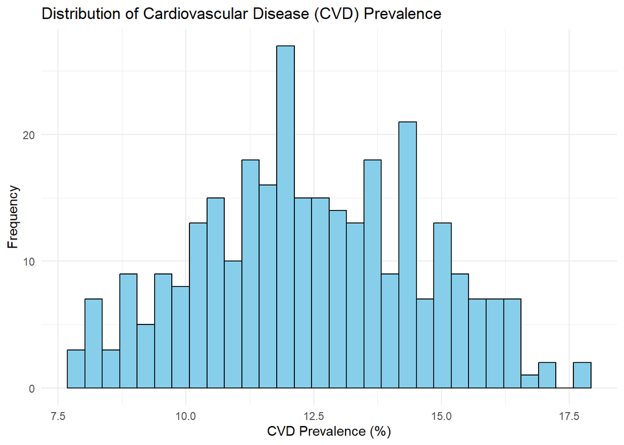

```r
# Plot histograms for each variable to check distribution
ggplot(data, aes(x = CVD)) +
  geom_histogram(bins = 30, fill = "skyblue", color = "black") +
  labs(title = "Distribution of Cardiovascular Disease (CVD) Prevalence", x = "CVD Prevalence (%)", y = "Frequency") +
  theme_minimal()
```

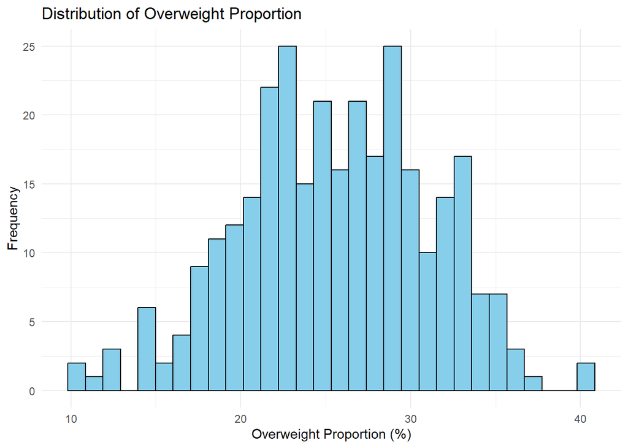

```r
ggplot(data, aes(x = overweight)) +
  geom_histogram(bins = 30, fill = "skyblue", color = "black") +
  labs(title = "Distribution of Overweight Proportion", x = "Overweight Proportion (%)", y = "Frequency") +
  theme_minimal()
```

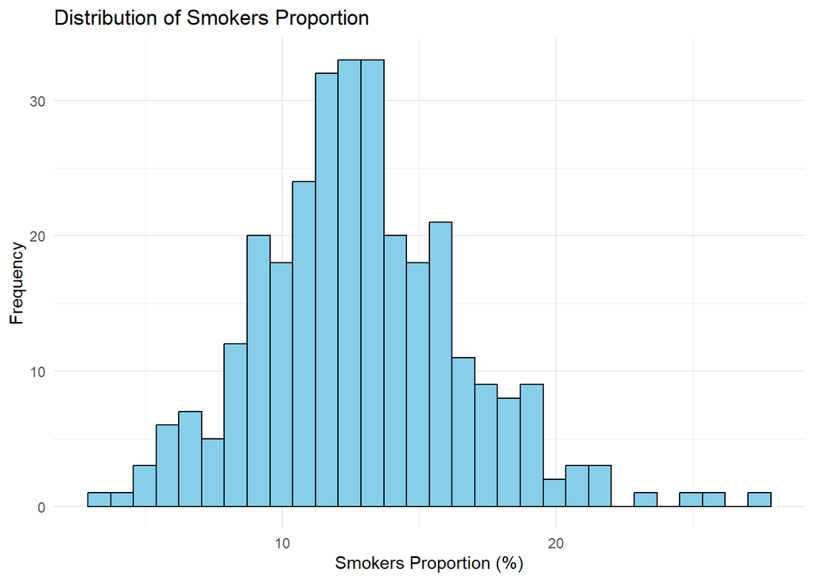

```r
ggplot(data, aes(x = smokers)) +
  geom_histogram(bins = 30, fill = "skyblue", color = "black") +
  labs(title = "Distribution of Smokers Proportion", x = "Smokers Proportion (%)", y = "Frequency") +
  theme_minimal()
```

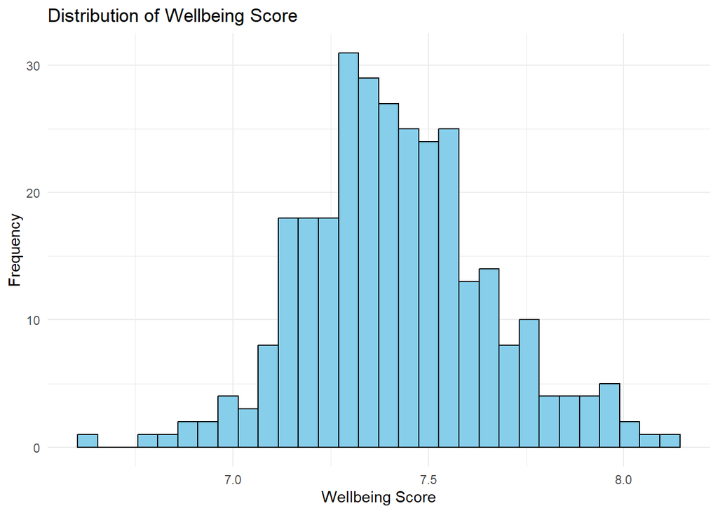

```r
ggplot(data, aes(x = wellbeing)) +
  geom_histogram(bins = 30, fill = "skyblue", color = "black") +
  labs(title = "Distribution of Wellbeing Score", x = "Wellbeing Score", y = "Frequency") +
  theme_minimal()
```

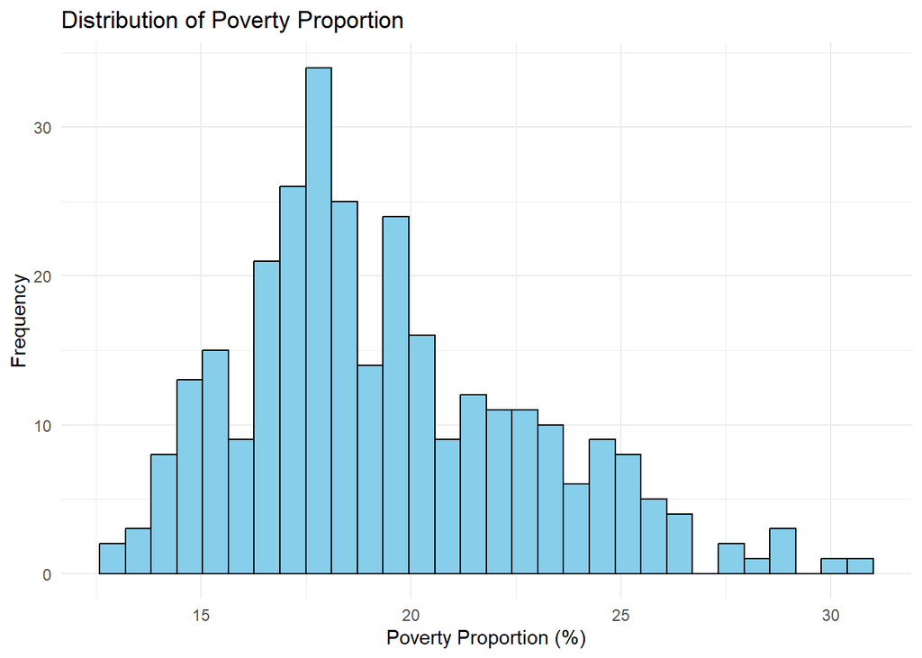

```r
ggplot(data, aes(x = Poverty)) +
  geom_histogram(bins = 30, fill = "skyblue", color = "black") +
  labs(title = "Distribution of Poverty Proportion", x = "Poverty Proportion (%)", y = "Frequency") +
  theme_minimal()
```

## Data Transformation

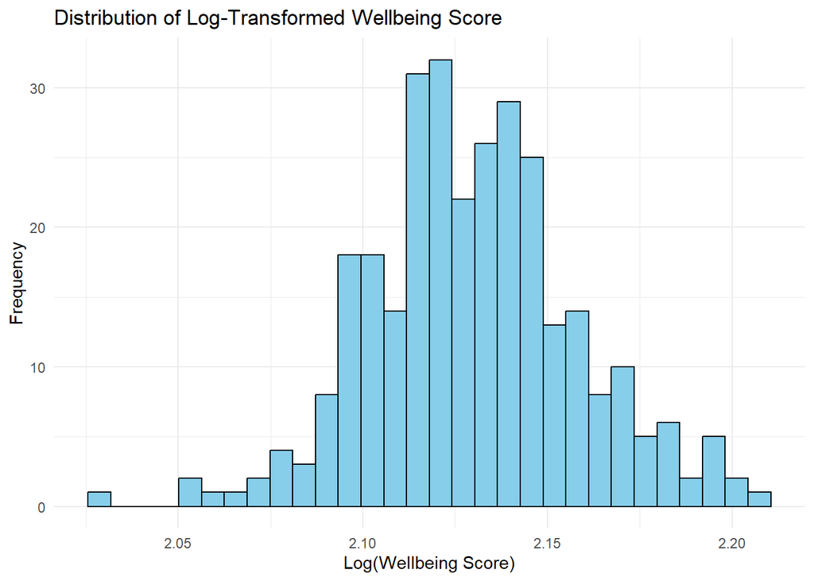

```r
# Apply log transformation to normalize Wellbeing and Poverty
# Adding a small constant to avoid log(0) -
#The logarithmic function (log(x)) is undefined for zero or negative values.
#Adding +1 ensures that all values in the dataset are shifted up by 1, eliminating any zero values and making the transformation valid for all data points.

data <- data %>%
  mutate(
    Wellbeing_log = log(wellbeing + 1),
    Poverty_log = log(Poverty + 1)
  )

# Plot histograms for the transformed variables
ggplot(data, aes(x = Wellbeing_log)) +
  geom_histogram(bins = 30, fill = "skyblue", color = "black") +
  labs(title = "Distribution of Log-Transformed Wellbeing Score", x = "Log(Wellbeing Score)", y = "Frequency") +
  theme_minimal()
```

- **Explanation:**
  - A log transformation compresses large values more than smaller values, reducing the skewness and making the data more symmetric, which is crucial for statistical analyses like regression that assume normally distributed variables.
  - The log transformation reduces skewness in Wellbeing, making it more suitable for regression analysis.
  - The distribution is now approximately normal, with the majority of values concentrated around the center (log values between 2.1 and 2.15).
  - The transformation makes the variable more compatible with statistical methods that assume normality, improving the reliability of the regression model.
  - The symmetrical distribution ensures that the variable contributes effectively as a predictor in modeling without bias introduced by outliers.

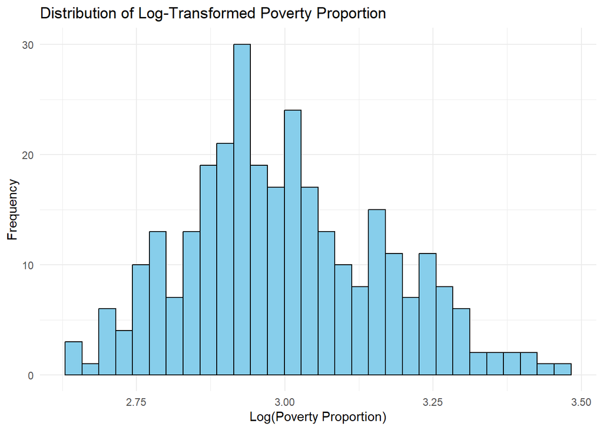

```r
ggplot(data, aes(x = Poverty_log)) +
  geom_histogram(bins = 30, fill = "skyblue", color = "black") +
  labs(title = "Distribution of Log-Transformed Poverty Proportion", x = "Log(Poverty Proportion)", y = "Frequency") +
  theme_minimal()
```

- **Explanation:**
  - Transforming Poverty similarly ensures it adheres to normality assumptions required for linear models.
  - The distribution is now closer to normal, with most values clustering around 3.0 (logarithmic scale).
  - The transformation ensures that the poverty variable conforms more closely to normality, making it a better fit for use in regression models.
  - By reducing skewness, the transformation minimizes the bias that could arise from outliers, improving the reliability and interpretability of the statistical analysis.

## Regression Analysis

- We are using linear regression because it is a well-suited method for analyzing the relationship between a dependent variable (CVD prevalence) and multiple independent variables (e.g., poverty, smokers, overweight, and wellbeing).

```r
# Fit a linear regression model with transformed variables
model <- lm(CVD ~ overweight + smokers + Wellbeing_log + Poverty_log, data = data)
```

## NHST (Null Hypothesis Significance Testing)

```r
# Extract coefficients and p-values
coefficients <- summary(model)$coefficients
coefficients
```

```
##                  Estimate Std. Error   t value     Pr(>|t|)
## (Intercept)   -13.8559533 9.71839427 -1.425745 1.549886e-01
## overweight      0.1121372 0.02135141  5.251981 2.868149e-07
## smokers         0.1193878 0.03394336  3.517267 5.039432e-04
## Wellbeing_log  15.4791417 4.14795314  3.731754 2.276769e-04
## Poverty_log    -3.6893668 0.74452020 -4.955362 1.212701e-06
```

```r
# Significant Predictors:
cat("Significant predictors with p-value < 0.05:\n")
```

```
## Significant predictors with p-value < 0.05:
```

```r
print(coefficients[coefficients[, 4] < 0.05, ])
```

```
##                 Estimate Std. Error   t value     Pr(>|t|)
## overweight     0.1121372 0.02135141  5.251981 2.868149e-07
## smokers        0.1193878 0.03394336  3.517267 5.039432e-04
## Wellbeing_log 15.4791417 4.14795314  3.731754 2.276769e-04
## Poverty_log   -3.6893668 0.74452020 -4.955362 1.212701e-06
```

- **Explanation:**
  - NHST evaluates whether each predictor’s effect on CVD prevalence is statistically significant.
  - If the p-value for a predictor is less than 0.05, we reject the null hypothesis and conclude that the predictor significantly affects CVD prevalence.

```r
# Summarize the regression analysis
model_summary <- summary(model)
model_summary
```

```
##
## Call:
## lm(formula = CVD ~ overweight + smokers + Wellbeing_log + Poverty_log,
##     data = data)
##
## Residuals:
##     Min      1Q  Median      3Q     Max
## -4.3721 -1.3957 -0.0764  1.3863  4.8315
##
## Coefficients:
##                Estimate Std. Error t value Pr(>|t|)
## (Intercept)   -13.85595    9.71839  -1.426 0.154989
## overweight      0.11214    0.02135   5.252 2.87e-07 ***
## smokers         0.11939    0.03394   3.517 0.000504 ***
## Wellbeing_log  15.47914    4.14795   3.732 0.000228 ***
## Poverty_log    -3.68937    0.74452  -4.955 1.21e-06 ***
## ---
## Signif. codes:  0 '***' 0.001 '**' 0.01 '*' 0.05 '.' 0.1 ' ' 1
##
## Residual standard error: 1.903 on 298 degrees of freedom
## Multiple R-squared:  0.2418, Adjusted R-squared:  0.2316
## F-statistic: 23.76 on 4 and 298 DF,  p-value: < 2.2e-16
```

- **Explanation:**
  - This regression model identifies the statistical significance of predictors (e.g., Overweight, Smokers, etc.) on CVD prevalence.
  - The regression analysis shows the relationship between several factors and cardiovascular disease (CVD) prevalence:
- **Key Findings:**
  - **Overweight:** For every 1% increase in the overweight proportion, CVD prevalence increases by 0.112%.
  - **Smokers:** A 1% rise in smoking is linked to a 0.119% increase in CVD prevalence.
  - **Wellbeing (Log-transformed):** Higher wellbeing scores significantly increase CVD prevalence (by 15.479% per unit increase).
  - **Poverty (Log-transformed):** Higher poverty levels are associated with a decrease in CVD prevalence (-3.689%).
- **Significance:**

All variables are statistically significant (p < 0.001), meaning they strongly influence CVD prevalence.

- **Model Fit:**
  - **R-squared (24.18%):** The model explains about 24% of the variation in CVD prevalence, indicating there are other factors at play.
- **Overall Conclusion:**
  - **Overweight, smoking, and wellbeing positively impact CVD, while poverty has a negative impact.**

## Multicolinearity

- Multicollinearity occurs in statistical modeling when two or more independent variables in a regression model are highly correlated. This creates challenges in estimating regression coefficients, making it hard to isolate and interpret the individual impact of each predictor on the dependent variable.

```r
# Calculate VIF
vif_values <- vif(model)

# Print VIF values
print(vif_values)
```

```
##    overweight       smokers Wellbeing_log   Poverty_log
##      1.197834      1.368128      1.140126      1.276781
```

- **Overweight (1.198):** Low VIF indicates minimal multicollinearity with other predictors.
- **Smokers (1.368):** Also has a low VIF, suggesting no significant multicollinearity.
- **Wellbeing_log (1.140):** Very low VIF, confirming no multicollinearity.
- **Poverty_log (1.277):** Low VIF, indicating that this variable also has minimal correlation with the other predictors.
- In this case, all predictors (overweight, smokers, Wellbeing_log, Poverty_log) have VIF values well below 5, meaning multicollinearity is not a concern for this model. We can confidently proceed with the analysis without making adjustments for multicollinearity.

## Analysis of Variance (ANOVA)

```r
anova_result <- anova(model)
print(anova_result)
```

```
## Analysis of Variance Table
##
## Response: CVD
##                Df  Sum Sq Mean Sq F value    Pr(>F)
## overweight      1  144.87 144.868 39.9958 9.293e-10 ***
## smokers         1    4.11   4.107  1.1338    0.2878
## Wellbeing_log   1  106.28 106.276 29.3411 1.252e-07 ***
## Poverty_log     1   88.94  88.942 24.5556 1.213e-06 ***
## Residuals     298 1079.38   3.622
## ---
## Signif. codes:  0 '***' 0.001 '**' 0.01 '*' 0.05 '.' 0.1 ' ' 1
```

- **Overweight:**
  - F-value = 39.9958; Pr(>F) = 9.293e-10 (***) indicates this variable is highly significant in explaining CVD prevalence.
- **Smokers:**
  - F-value = 1.1338; Pr(>F) = 0.2878 indicates this variable is not significant in explaining CVD.
- **Wellbeing_log:**
  - F-value = 29.3411; Pr(>F) = 1.252e-07 (***) indicates a strong and significant relationship with CVD.
- **Poverty_log:**
  - F-value = 24.5556; Pr(>F) = 1.213e-06 (***) indicates a significant effect on CVD prevalence.
- **Residuals:**
  - The residual sum of squares (1079.38) represents unexplained variability in the dependent variable.
- Overweight, Wellbeing_log, and Poverty_log are statistically significant predictors of CVD prevalence (p < 0.001).
- Smokers does not significantly contribute to explaining the variation in CVD prevalence (p = 0.2878).

## Estimation Approach

```r
# Extract confidence intervals for coefficients
cat("95% Confidence Intervals for predictors:\n")
```

```
## 95% Confidence Intervals for predictors:
```

```r
conf_intervals <- confint(model)
conf_intervals
```

```
##                      2.5 %     97.5 %
## (Intercept)   -32.98133054  5.2694239
## overweight      0.07011854  0.1541558
## smokers         0.05258878  0.1861869
## Wellbeing_log   7.31615039 23.6421331
## Poverty_log    -5.15455014 -2.2241834
```

- **Explanation:**
  - 2.5%: The lower bound of the confidence interval (CI).
  - 97.5%: The upper bound of the confidence interval (CI).
  - The estimation approach provides 95% confidence intervals for each predictor’s effect on CVD.
  - This helps interpret the practical significance and magnitude of each variable’s impact.
  - Variables like overweight, smokers, Wellbeing_log, and Poverty_log have confidence intervals that do not cross 0, indicating they are significant predictors in the model.
  - The width of each interval reflects the precision of the estimate—narrower intervals indicate greater confidence in the coefficient estimate.

## Conclusion

- Overweight is the biggest factor affecting the number of people with cardiovascular disease (CVD) in the area.
- The data shows a strong link between being overweight and higher rates of CVD.
- Poverty also affects CVD, but its impact is smaller compared to overweight.
- To reduce CVD cases, focusing on helping people manage their weight would be the most effective step, along with efforts to reduce poverty for better long-term health.

## Visualization of Effect of Poverty on CVD

```r
# Create a plot showing the relationship between Poverty and CVD prevalence
poverty_plot <- ggplot(data, aes(x = Poverty, y = CVD)) +
  geom_point() +
  geom_smooth(method = "lm", col = "blue", se = TRUE) +
  labs(
    title = "Effect of Poverty on Cardiovascular Disease Prevalence",
    x = "Proportion Living in Poverty (%)",
    y = "CVD Prevalence (%)"
  ) +
  theme_minimal()
```

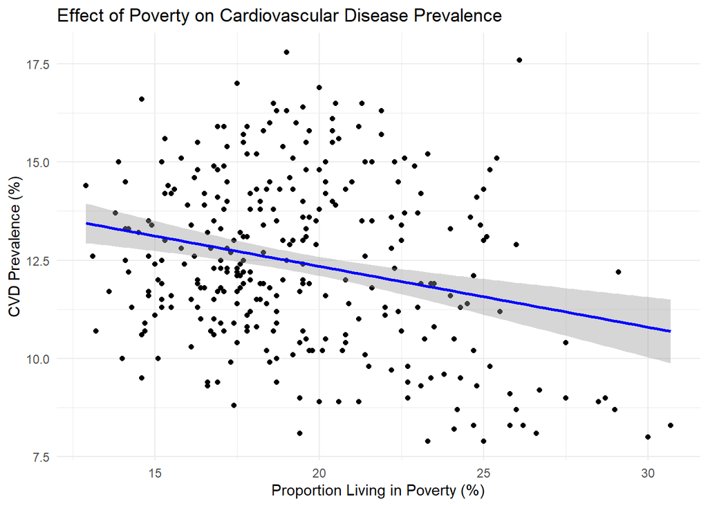

```r
# Print the plot
poverty_plot
```

- **Summary**:
  - The scatterplot shows the relationship between poverty levels (proportion living in poverty, %) and CVD prevalence (%).
  - The blue line represents the linear trend, indicating a negative relationship: as the level of poverty increases, the prevalence of CVD tends to decrease slightly.
  - The shaded area around the blue line represents the confidence interval, showing the uncertainty in the linear regression predictions.
  - This plot suggests that poverty may have a negative association with CVD prevalence, contrary to what might be intuitively expected. This result could be influenced by other confounding factors and should be interpreted carefully alongside statistical models.

# Question 2

## Data Dictionary

| Variable | Description |
| --- | --- |
| SES_category | Socioeconomic status of the store’s location (low, medium, high). |
| customer.satisfaction | Average customer satisfaction score. |
| staff.satisfaction | Average staff job satisfaction score. |
| delivery.time | Average delivery time for large and custom items (in minutes). |
| new_range | Whether the store carries a new range of products (TRUE/FALSE). |

```r
# Load the data1set
data1 <- read.csv("cust_satisfaction.csv")
```

```r
# Examine the structure of the data1
str(data1)
```

```
## 'data.frame':    300 obs. of  5 variables:
##  $ SES_category         : chr  "Medium" "Medium" "Medium" "High" ...
##  $ customer.satisfaction: num  7.27 7.93 7.12 6.35 6.78 ...
##  $ staff.satisfaction   : num  6.88 7.44 7.15 6.47 7.06 ...
##  $ delivery.time        : num  66.7 68.2 70.7 61.4 57.7 ...
##  $ new_range            : logi  FALSE FALSE FALSE TRUE TRUE TRUE ...
```

```r
# Summary of the data1
summary(data1)
```

```
##  SES_category       customer.satisfaction staff.satisfaction delivery.time
##  Length:300         Min.   :3.760         Min.   :4.850      Min.   :32.96
##  Class :character   1st Qu.:6.099         1st Qu.:6.216      1st Qu.:52.46
##  Mode  :character   Median :7.006         Median :6.634      Median :60.45
##                     Mean   :6.930         Mean   :6.751      Mean   :59.60
##                     3rd Qu.:7.865         3rd Qu.:7.274      3rd Qu.:66.79
##                     Max.   :9.670         Max.   :8.860      Max.   :92.48
##  new_range
##  Mode :logical
##  FALSE:142
##  TRUE :158
##
##
##
```

- **Key Insights:**
  - Most customer and staff satisfaction scores are around the median values, indicating a relatively balanced distribution.
  - Delivery times show a range from fast (33 minutes) to slow (92 minutes), with an average of about 60 minutes.
  - There is almost an even split between stores carrying (TRUE: 158) and not carrying (FALSE: 142) the new product range.
  - This summary provides a quick overview of the cust_satisfaction data and helps identify trends, variability, and potential areas for further analysis.

## Checking Missing Values

```r
# Show row counts with missing values before any operation
missing_counts <- colSums(is.na(data1))

print("Row counts with missing values")
```

```
## [1] "Row counts with missing values"
```

```r
print(missing_counts)
```

```
##          SES_category customer.satisfaction    staff.satisfaction
##                     0                     0                     0
##         delivery.time             new_range
##                     0                     0
```

- There are no missing values, hence no operation is required.

## Converting new_range and SES_category as factors

```r
data1$new_range <- as.factor(data1$new_range)
data1$SES_category <- as.factor(data1$SES_category)

str(data1)
```

```
## 'data.frame':    300 obs. of  5 variables:
##  $ SES_category         : Factor w/ 3 levels "High","Low","Medium": 3 3 3 1 1 3 3 3 3 1 ...
##  $ customer.satisfaction: num  7.27 7.93 7.12 6.35 6.78 ...
##  $ staff.satisfaction   : num  6.88 7.44 7.15 6.47 7.06 ...
##  $ delivery.time        : num  66.7 68.2 70.7 61.4 57.7 ...
##  $ new_range            : Factor w/ 2 levels "FALSE","TRUE": 1 1 1 2 2 2 2 1 1 2 ...
```

- new_range: Treated as a binary factor with two levels (“FALSE”, “TRUE”).
- SES_category: Treated as a factor with three levels (“High”, “Low”, “Medium”).

## Correlation analysis between numeric variables

- **Why perform correlation analysis?** Correlation analysis helps us understand the strength and direction of the linear relationship between numeric variables.
- This provides an initial insight into how variables like staff satisfaction and delivery time may be related to customer satisfaction, helping us determine which variables to include in further analysis.

```r
correlation_matrix <- data1 %>%
  select(customer.satisfaction, staff.satisfaction, delivery.time) %>%
  cor()
print(correlation_matrix)
```

```
##                       customer.satisfaction staff.satisfaction delivery.time
## customer.satisfaction             1.0000000         0.45404708   -0.25890017
## staff.satisfaction                0.4540471         1.00000000   -0.06520613
## delivery.time                    -0.2589002        -0.06520613    1.00000000
```

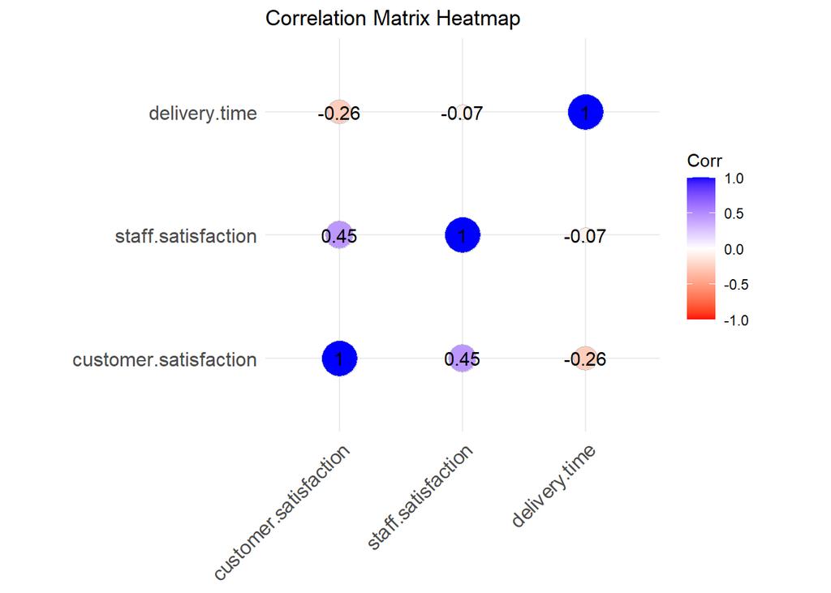

```r
# Generate the heatmap
ggcorrplot(correlation_matrix,
           method = "circle",
           lab = TRUE,
           title = "Correlation Matrix Heatmap",
           colors = c("red", "white", "blue"))
```

- This matrix represents the correlation coefficients between the numeric variables in the data1set. Correlation coefficients range from -1 to 1 and indicate the strength and direction of the linear relationship between two variables.
- **Insights:**
  - The strongest relationship is between customer satisfaction and staff satisfaction, indicating that improving staff satisfaction could positively impact customer satisfaction.
  - Delivery time has a weaker relationship with customer satisfaction, but the negative correlation suggests that faster deliveries may slightly improve customer satisfaction.
  - The relationship between staff satisfaction and delivery time is negligible.

## Regression Analysis

- **Why perform multiple linear regression?** Multiple linear regression allows us to assess the combined and individual impact of multiple independent variables (e.g., staff satisfaction, delivery time, new range, and SES category) on the dependent variable (customer satisfaction).
- This helps identify the most significant predictors of customer satisfaction while controlling for the effects of other variables.

```r
model1 <- lm(customer.satisfaction ~ staff.satisfaction + delivery.time + new_range + SES_category, data = data1)
```

## NHST (Null Hypothesis Significance Testing)

```r
# Extracting p-values from the model to test the null hypothesis for each predictor.
hypothesis_tests <- summary(model1)$coefficients[, "Pr(>|t|)"]
print(hypothesis_tests)
```

```
##        (Intercept) staff.satisfaction      delivery.time      new_rangeTRUE
##       6.865783e-16       1.770268e-05       5.772007e-04       4.036432e-01
##    SES_categoryLow SES_categoryMedium
##       6.587804e-02       8.432125e-15
```

```r
# Interpretation: Small p-values (< 0.05) indicate we can reject the null hypothesis that the predictor has no effect.
```

- **Significant predictors:** Staff Satisfaction, Delivery Time, and Medium SES.
- **Marginally significant:** Low SES.
- **Not significant:** New Range.
- This output helps identify which variables meaningfully affect customer satisfaction and guide business decisions to improve it.

```r
# Summarize the model
summary(model1)
```

```
##
## Call:
## lm(formula = customer.satisfaction ~ staff.satisfaction + delivery.time +
##     new_range + SES_category, data = data1)
##
## Residuals:
##      Min       1Q   Median       3Q      Max
## -2.59866 -0.67952 -0.01176  0.65469  2.89231
##
## Coefficients:
##                     Estimate Std. Error t value Pr(>|t|)
## (Intercept)         5.218333   0.610361   8.550 6.87e-16 ***
## staff.satisfaction  0.351113   0.080457   4.364 1.77e-05 ***
## delivery.time      -0.017220   0.004948  -3.480 0.000577 ***
## new_rangeTRUE       0.093878   0.112249   0.836 0.403643
## SES_categoryLow    -0.255765   0.138541  -1.846 0.065878 .
## SES_categoryMedium  1.209293   0.147773   8.183 8.43e-15 ***
## ---
## Signif. codes:  0 '***' 0.001 '**' 0.01 '*' 0.05 '.' 0.1 ' ' 1
##
## Residual standard error: 0.9687 on 294 degrees of freedom
## Multiple R-squared:  0.447,  Adjusted R-squared:  0.4376
## F-statistic: 47.53 on 5 and 294 DF,  p-value: < 2.2e-16
```

- **Key Findings:**
  - **Staff Satisfaction:** A positive relationship exists: Higher staff satisfaction increases customer satisfaction. (Significant)
  - **Delivery Time:** A negative relationship exists: Longer delivery times reduce customer satisfaction. (Significant)
  - **New Product Range:** Stores carrying a new product range have slightly higher customer satisfaction, but this effect is not significant.
  - **Socioeconomic Status (SES):** Stores in medium SES areas have significantly higher customer satisfaction than those in high SES areas. Stores in low SES areas have slightly lower satisfaction compared to high SES areas, but this effect is only marginally significant.

## Estimation Approach

```r
# Extract confidence intervals for coefficients
cat("95% Confidence Intervals for predictors:\n")
```

```
## 95% Confidence Intervals for predictors:
```

```r
confintervals <- confint(model1)
confintervals
```

```
##                          2.5 %       97.5 %
## (Intercept)         4.01710195  6.419563868
## staff.satisfaction  0.19276839  0.509457959
## delivery.time      -0.02695804 -0.007481643
## new_rangeTRUE      -0.12703512  0.314791616
## SES_categoryLow    -0.52842293  0.016892708
## SES_categoryMedium  0.91846670  1.500119628
```

- **Significant Predictors:** staff.satisfaction, delivery.time, and SES_categoryMedium are statistically significant because their confidence intervals do not include 0.
- **Non-Significant Predictors:** new_rangeTRUE and SES_categoryLow are not statistically significant because their confidence intervals include 0.
- **Direction of Effect:**
  - Positive predictors (e.g., staff.satisfaction and SES_categoryMedium) are associated with an increase in the dependent variable.
  - Negative predictors (e.g., delivery.time) are associated with a decrease in the dependent variable.

## Analysis of Variance (ANOVA)

```r
anova_result2 <- anova(model1)
print(anova_result2)
```

```
## Analysis of Variance Table
##
## Response: customer.satisfaction
##                     Df  Sum Sq Mean Sq  F value    Pr(>F)
## staff.satisfaction   1 102.841 102.841 109.6033 < 2.2e-16 ***
## delivery.time        1  26.339  26.339  28.0709 2.297e-07 ***
## new_range            1   0.347   0.347   0.3696    0.5437
## SES_category         2  93.456  46.728  49.8006 < 2.2e-16 ***
## Residuals          294 275.860   0.938
## ---
## Signif. codes:  0 '***' 0.001 '**' 0.01 '*' 0.05 '.' 0.1 ' ' 1
```

- F-value = 109.60; p-value < 2.2e-16 (***) indicates this variable is highly significant. This suggests that staff.satisfaction has a strong and meaningful impact on customer.satisfaction.
- F-value = 28.07; p-value = 2.297e-07 (***) indicates it is also highly significant.The negative relationship (from earlier analysis) suggests that faster delivery times improve customer satisfaction.
- F-value = 0.37; p-value = 0.5437 indicates this variable is not significant. It likely does not have a meaningful impact on customer satisfaction.
- F-value = 49.80; p-value < 2.2e-16 (***) indicates a highly significant effect. SES category is an important predictor of customer satisfaction.
- The residual sum of squares (275.86) represents the variability in customer.satisfaction not explained by the predictors.
- Significant predictors: staff.satisfaction, delivery.time, and SES_category significantly affect customer.satisfaction.
- Non-significant predictor: new_range does not have a statistically significant effect.

## Check assumptions of linear regression

### 1. Linearity and Homoscedasticity

- Linearity assumes that the relationship between the predictors (independent variables) and the outcome (dependent variable) is linear. This ensures the model is appropriately capturing the relationship.

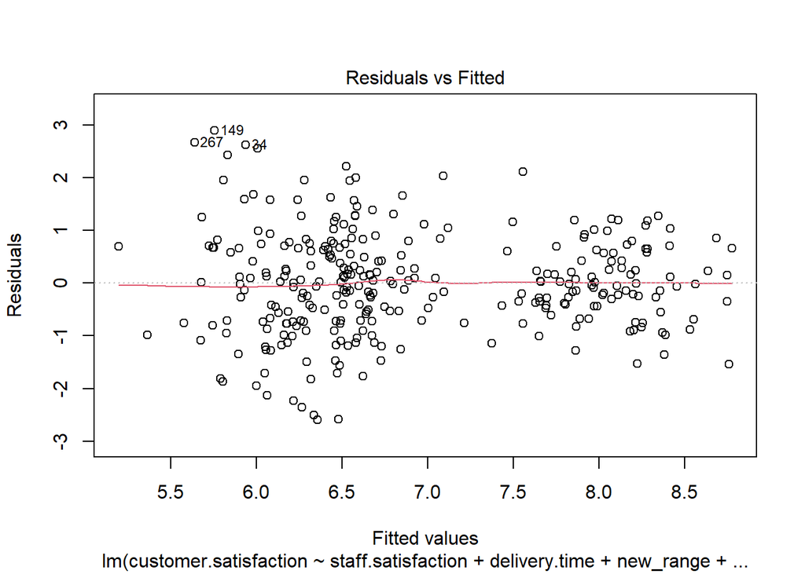

```r
plot(model1, which = 1)
```

- This Residuals vs. Fitted plot is a diagnostic tool for assessing the assumptions of linear regression, specifically linearity and homoscedasticity.
  - **Residuals (y-axis):** The differences between the observed and predicted values of the dependent variable (customer.satisfaction).
  - **Fitted Values (x-axis):** The predicted values of customer.satisfaction based on the regression model.
- The residuals appear randomly scattered, suggesting the linearity assumption is reasonable.
- The residuals seem to have consistent variance across the range of fitted values, satisfying the homoscedasticity assumption.
- The plot suggests that the assumptions of linearity and homoscedasticity are generally met.

### 2. Normality of Residuals

- Normality assumes that the residuals (errors) follow a normal distribution. This is crucial for making accurate statistical inferences (e.g., p-values, confidence intervals).

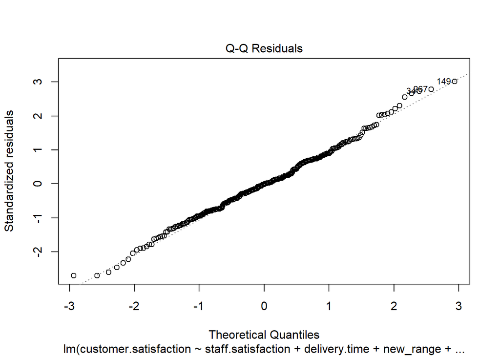

```r
plot(model1, which = 2)
```

- The Q-Q (Quantile-Quantile) plot of residuals is used to check whether the residuals from the regression model follow a normal distribution.
  - **Standardized Residuals (y-axis):** These are the residuals (differences between actual and predicted values) that have been standardized to have a mean of 0 and a standard deviation of 1.
  - **Theoretical Quantiles (x-axis):**These are the expected quantiles if the residuals were perfectly normally distributed.
  - **45-degree Line:**The dotted line represents the ideal scenario where the residuals perfectly follow a normal distribution.
- Most points align well with the line in the middle, suggesting that the residuals are approximately normal for the bulk of the data1.

## Supporting Visualizations

### Scatter plot: Customer Satisfaction vs Staff Satisfaction

- **Why scatter plots?** Scatter plots are used to visualize the relationship between two continuous variables.

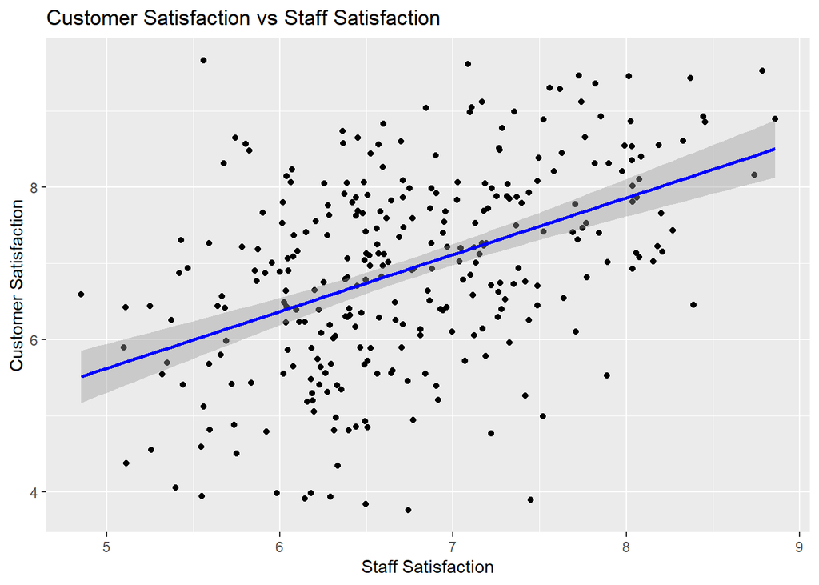

```r
ggplot(data1, aes(x = staff.satisfaction, y = customer.satisfaction)) +
  geom_point() +
  geom_smooth(method = "lm", col = "blue") +
  labs(title = "Customer Satisfaction vs Staff Satisfaction",
       x = "Staff Satisfaction",
       y = "Customer Satisfaction")
```

- **Explaination:**
  - This plot helps us understand if there is a linear relationship between staff satisfaction and customer satisfaction.
- **data1 Points:**
  - Each black dot represents a store.
  - The position of the dot indicates the store’s values for Staff Satisfaction (x-axis) and Customer Satisfaction (y-axis).
- **Regression Line:**
  - The blue line represents the fitted linear regression model.
  - This line shows the trend or relationship between Staff Satisfaction and Customer Satisfaction.
- **Shaded Area:**
  - The gray area around the regression line represents the confidence interval.
  - It shows the range within which the true regression line is likely to fall.
- **Key Observations:**
- **Positive Relationship:**
  - The regression line slopes upward, indicating a positive relationship between Staff Satisfaction and Customer Satisfaction.
  - Higher staff satisfaction is associated with higher customer satisfaction.
- **Strength of Relationship:**
  - While there is a clear upward trend, the scatter of points around the line suggests some variability, meaning other factors likely also influence customer satisfaction.

### Boxplot: Customer Satisfaction by SES Category

- **Why boxplots?** Boxplots are ideal for comparing the distribution of a continuous variable across categorical groups.

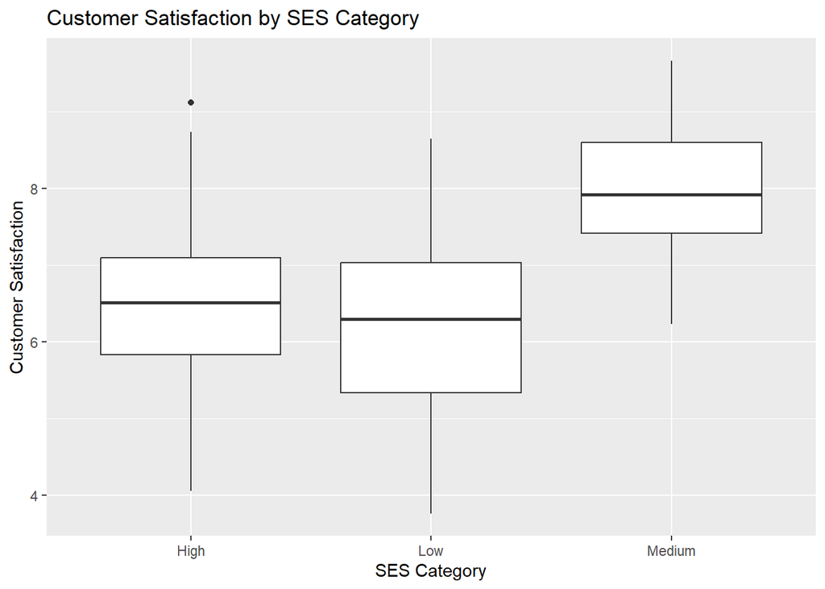

```r
ggplot(data1, aes(x = SES_category, y = customer.satisfaction)) +
  geom_boxplot() +
  labs(title = "Customer Satisfaction by SES Category",
       x = "SES Category",
       y = "Customer Satisfaction")
```

### Boxplot: Customer Satisfaction by New Range

- Boxplots are again used here to compare customer satisfaction across the presence or absence of a new range.

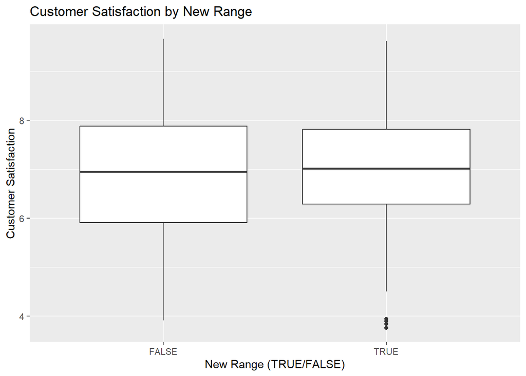

```r
ggplot(data1, aes(x = factor(new_range), y = customer.satisfaction)) +
  geom_boxplot() +
  labs(title = "Customer Satisfaction by New Range",
       x = "New Range (TRUE/FALSE)",
       y = "Customer Satisfaction")
```

- **Explaination:**
  - This plot helps identify if carrying a new product range impacts customer satisfaction.
  - The lack of a significant difference in medians aligns with the earlier analysis showing that new_rangeTRUE is not statistically significant (its confidence interval included 0).

### Scatter plot: Customer Satisfaction vs Delivery Time

- Scatter plots are used here to evaluate the relationship between delivery time and customer satisfaction.

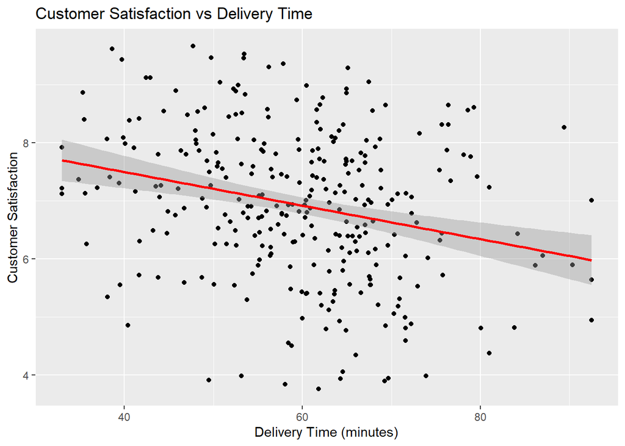

```r
ggplot(data1, aes(x = delivery.time, y = customer.satisfaction)) +
  geom_point() +
  geom_smooth(method = "lm", col = "red") +
  labs(title = "Customer Satisfaction vs Delivery Time",
       x = "Delivery Time (minutes)",
       y = "Customer Satisfaction")
```

- **Explaination:**
  - This plot reveals whether longer delivery times are associated with lower customer satisfaction.
- **data1 Points:**
  - Each black dot represents a store.
  - The position of the dot shows its corresponding delivery time and customer satisfaction score.
- **Regression Line:**
  - The red line represents the overall linear regression fit.
  - It shows the trend in how delivery time impacts customer satisfaction.
- **Shaded Area:**
  - The gray area around the line represents the confidence interval of the regression line.
  - It indicates the range within which the true relationship is likely to lie.
- **Key Observations:**
- **Negative Slope:**
  - The red line slopes downward, indicating a negative relationship between delivery time and customer satisfaction.
  - As delivery time increases, customer satisfaction tends to decrease.
- **Spread of Points:**
  - The scatter of points around the line shows variability in customer satisfaction that is not explained by delivery time alone.
  - Other factors (e.g., SES category, staff satisfaction) likely also influence customer satisfaction.
- **Conclusions:**
  - Delivery time has a negative effect on customer satisfaction: longer delivery times are associated with lower satisfaction levels.
  - The effect size and variability might differ across stores categorized by SES, which is explored in the full analysis using an interaction model.

## Interaction between Delivery Time and SES Category with Customer Satisfaction

```r
# Fit a linear model with interaction between delivery time and SES category
interaction_model <- lm(customer.satisfaction ~ delivery.time * SES_category, data = data1)

# Summarize the model
interaction_summary <- summary(interaction_model)
interaction_summary
```

```
##
## Call:
## lm(formula = customer.satisfaction ~ delivery.time * SES_category,
##     data = data1)
##
## Residuals:
##      Min       1Q   Median       3Q      Max
## -2.43290 -0.63000  0.00057  0.72673  2.52903
##
## Coefficients:
##                                  Estimate Std. Error t value Pr(>|t|)
## (Intercept)                       8.62092    0.57199  15.072  < 2e-16 ***
## delivery.time                    -0.03471    0.00946  -3.669 0.000289 ***
## SES_categoryLow                  -2.12232    0.77457  -2.740 0.006519 **
## SES_categoryMedium                0.29635    0.76383   0.388 0.698310
## delivery.time:SES_categoryLow     0.02976    0.01253   2.374 0.018221 *
## delivery.time:SES_categoryMedium  0.01937    0.01287   1.505 0.133336
## ---
## Signif. codes:  0 '***' 0.001 '**' 0.01 '*' 0.05 '.' 0.1 ' ' 1
##
## Residual standard error: 0.9916 on 294 degrees of freedom
## Multiple R-squared:  0.4205, Adjusted R-squared:  0.4107
## F-statistic: 42.67 on 5 and 294 DF,  p-value: < 2.2e-16
```

### Model Interpretation

- **Key Terms**:
  - `delivery.time`: Main effect of delivery time on customer satisfaction.
  - `SES_category`: Differences in customer satisfaction across SES categories.
  - `delivery.time:SES_category`: Interaction term, indicating whether the effect of delivery time varies across SES categories.

```r
# Extract coefficients and p-values for interaction terms
interaction_coefficients <- interaction_summary$coefficients
interaction_coefficients
```

```
##                                     Estimate  Std. Error    t value
## (Intercept)                       8.62092466 0.571987018 15.0718887
## delivery.time                    -0.03470626 0.009459785 -3.6688216
## SES_categoryLow                  -2.12232317 0.774568661 -2.7400065
## SES_categoryMedium                0.29635382 0.763832760  0.3879826
## delivery.time:SES_categoryLow     0.02976183 0.012534617  2.3743708
## delivery.time:SES_categoryMedium  0.01937249 0.012870030  1.5052402
##                                      Pr(>|t|)
## (Intercept)                      1.985741e-38
## delivery.time                    2.892217e-04
## SES_categoryLow                  6.519458e-03
## SES_categoryMedium               6.983097e-01
## delivery.time:SES_categoryLow    1.822084e-02
## delivery.time:SES_categoryMedium 1.333359e-01
```

## Visualization

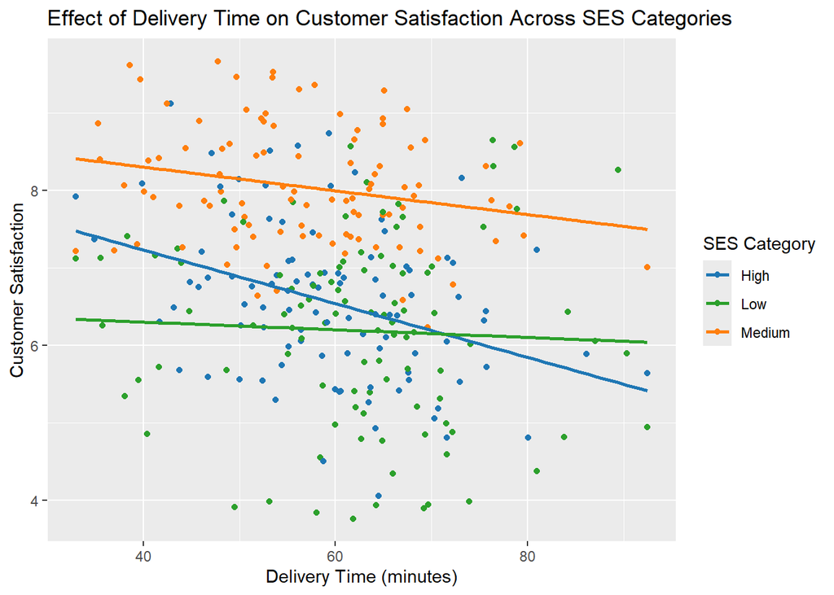

```r
# Create a plot to visualize the interaction
interaction_plot <- ggplot(data1, aes(x = delivery.time, y = customer.satisfaction, color = SES_category)) +
  geom_point() +
  geom_smooth(method = "lm", aes(group = SES_category), se = FALSE) +
  scale_color_manual(values = c("High" = "#1f77b4", "Medium" = "#ff7f0e", "Low" = "#2ca02c")) +
  labs(
    title = "Effect of Delivery Time on Customer Satisfaction Across SES Categories",
    x = "Delivery Time (minutes)",
    y = "Customer Satisfaction",
    color = "SES Category"
  )
interaction_plot
```

## Analysis of Variance (ANOVA)

```r
aov_model <- aov(customer.satisfaction ~ delivery.time*SES_category, data=data1)
summary(aov_model)
```

```
##                             Df Sum Sq Mean Sq F value   Pr(>F)
## delivery.time                1  33.44   33.44  34.009 1.44e-08 ***
## SES_category                 2 170.75   85.38  86.836  < 2e-16 ***
## delivery.time:SES_category   2   5.59    2.80   2.844   0.0598 .
## Residuals                  294 289.06    0.98
## ---
## Signif. codes:  0 '***' 0.001 '**' 0.01 '*' 0.05 '.' 0.1 ' ' 1
```

- **Delivery Time:**
- Pr(>F) = 1.44e-08 (p < 0.001): Highly significant.
- Suggests that delivery.time has a strong effect on customer.satisfaction.
- **SES Category:**
- Pr(>F) < 2e-16 (p < 0.001): Highly significant.
- Indicates that SES_category significantly affects customer.satisfaction.
- **Interaction (delivery.time:SES_category):**
- Pr(>F) = 0.0598 (p < 0.1): Marginally significant.
- Suggests a weak interaction between delivery.time and SES_category. The effect of delivery time on customer satisfaction might - slightly depend on SES category.